# Risk Factor Analysis

## Outcome Variable

**Outcome Variable:** whz

## Predictor Variables

**Intervention Variable:** fhtcm

**Adjustment Set:**

- arm
- W_mage
- W_fage
- meducyrs
- feducyrs
- W_mhtcm
- W_mwtkg
- W_mbmi
- single
- W_gagebrth
- W_birthwt
- W_birthlen
- vagbrth
- delta_W_mage
- delta_W_fage
- delta_meducyrs
- delta_feducyrs
- delta_W_mhtcm
- delta_W_mwtkg
- delta_W_mbmi
- delta_single
- delta_W_gagebrth
- delta_W_birthwt
- delta_W_birthlen
- delta_vagbrth

## Stratifying Variables

The analysis was stratified on these variable(s):

- agecat
- studyid
- country

## Data Summary

| agecat | studyid | country | fhtcm | n_cell | n |
| --- | --- | --- | --- | --- | --- |
| 6 months | ki1000304b-SAS-CompFeed | INDIA | >=167 cm | 370 | 807 |
| 6 months | ki1000304b-SAS-CompFeed | INDIA | <162 cm | 193 | 807 |
| 6 months | ki1000304b-SAS-CompFeed | INDIA | [162-167) cm | 244 | 807 |
| 6 months | ki1000304b-SAS-FoodSuppl | INDIA | >=167 cm | 102 | 371 |
| 6 months | ki1000304b-SAS-FoodSuppl | INDIA | <162 cm | 148 | 371 |
| 6 months | ki1000304b-SAS-FoodSuppl | INDIA | [162-167) cm | 121 | 371 |
| 6 months | ki1101329-Keneba | GAMBIA | >=167 cm | 979 | 1510 |
| 6 months | ki1101329-Keneba | GAMBIA | <162 cm | 113 | 1510 |
| 6 months | ki1101329-Keneba | GAMBIA | [162-167) cm | 418 | 1510 |
| 6 months | ki1119695-PROBIT | BELARUS | >=167 cm | 11143 | 11892 |
| 6 months | ki1119695-PROBIT | BELARUS | <162 cm | 156 | 11892 |
| 6 months | ki1119695-PROBIT | BELARUS | [162-167) cm | 593 | 11892 |
| 6 months | ki1135781-COHORTS | GUATEMALA | >=167 cm | 44 | 336 |
| 6 months | ki1135781-COHORTS | GUATEMALA | <162 cm | 198 | 336 |
| 6 months | ki1135781-COHORTS | GUATEMALA | [162-167) cm | 94 | 336 |
| 24 months | ki1101329-Keneba | GAMBIA | >=167 cm | 823 | 1298 |
| 24 months | ki1101329-Keneba | GAMBIA | <162 cm | 96 | 1298 |
| 24 months | ki1101329-Keneba | GAMBIA | [162-167) cm | 379 | 1298 |
| 24 months | ki1119695-PROBIT | BELARUS | >=167 cm | 3387 | 3609 |
| 24 months | ki1119695-PROBIT | BELARUS | <162 cm | 52 | 3609 |
| 24 months | ki1119695-PROBIT | BELARUS | [162-167) cm | 170 | 3609 |
| 24 months | ki1135781-COHORTS | GUATEMALA | >=167 cm | 72 | 532 |
| 24 months | ki1135781-COHORTS | GUATEMALA | <162 cm | 311 | 532 |
| 24 months | ki1135781-COHORTS | GUATEMALA | [162-167) cm | 149 | 532 |

The following strata were considered:

- agecat: 24 months, studyid: ki1101329-Keneba, country: GAMBIA
- agecat: 24 months, studyid: ki1119695-PROBIT, country: BELARUS
- agecat: 24 months, studyid: ki1135781-COHORTS, country: GUATEMALA
- agecat: 6 months, studyid: ki1000304b-SAS-CompFeed, country: INDIA
- agecat: 6 months, studyid: ki1000304b-SAS-FoodSuppl, country: INDIA
- agecat: 6 months, studyid: ki1101329-Keneba, country: GAMBIA
- agecat: 6 months, studyid: ki1119695-PROBIT, country: BELARUS
- agecat: 6 months, studyid: ki1135781-COHORTS, country: GUATEMALA

## Methods Detail

We’re interested in the causal parameters $E[Y_a]$ for all values of $a \in \mathcal{A}$. These parameters represent the mean outcome if, possibly contrary to fact, we intervened to set all units to have $A=a$. Under the randomization and positivity assumptions, these are identified by the statistical parameters $\psi_a=E_W[E_{Y|A,W}(Y|A=a,W)]$. In addition, we’re interested in the mean of $Y$, $E[Y]$ under no intervention (the observed mean). We will estimate these parameters by using SuperLearner to fit the relevant likelihood factors – $E_{Y|A,W}(Y|A=a,W)$ and $p(A=a|W)$, and then updating our likelihood fit using a joint TMLE.

For unadjusted analyses ($W=\{\}$), initial likelihoods were estimated using Lrnr_glm to estimate the simple $E(Y|A)$ and Lrnr_mean to estimate $p(A)$. For adjusted analyses, a small library containing Lrnr_glmnet, Lrnr_xgboost, and Lrnr_mean was used.

# Results Detail

## Results Plots

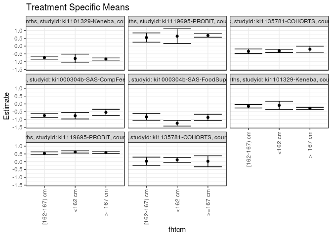

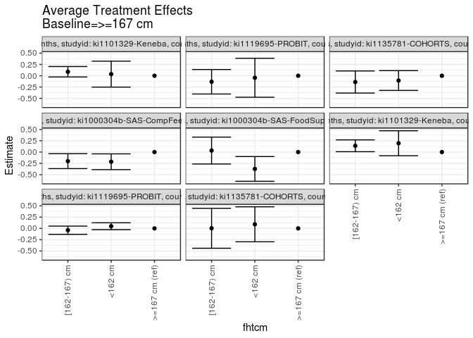

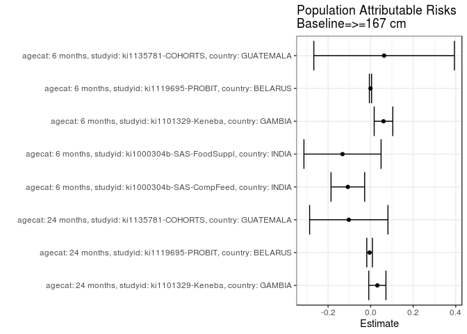

## Results Table

### Parameter: TSM

| agecat | studyid | country | intervention_level | baseline_level | estimate | ci_lower | ci_upper |
| --- | --- | --- | --- | --- | --- | --- | --- |
| 6 months | ki1000304b-SAS-CompFeed | INDIA | >=167 cm | NA | -0.5431049 | -0.7417606 | -0.3444491 |
| 6 months | ki1000304b-SAS-CompFeed | INDIA | <162 cm | NA | -0.7569103 | -0.9671144 | -0.5467063 |
| 6 months | ki1000304b-SAS-CompFeed | INDIA | [162-167) cm | NA | -0.7438568 | -0.8607601 | -0.6269535 |
| 6 months | ki1000304b-SAS-FoodSuppl | INDIA | >=167 cm | NA | -0.8675588 | -1.0707680 | -0.6643496 |
| 6 months | ki1000304b-SAS-FoodSuppl | INDIA | <162 cm | NA | -1.2402787 | -1.4244697 | -1.0560877 |
| 6 months | ki1000304b-SAS-FoodSuppl | INDIA | [162-167) cm | NA | -0.8339917 | -1.0505838 | -0.6173995 |
| 6 months | ki1101329-Keneba | GAMBIA | >=167 cm | NA | -0.2877454 | -0.3598812 | -0.2156096 |
| 6 months | ki1101329-Keneba | GAMBIA | <162 cm | NA | -0.0925046 | -0.3597654 | 0.1747562 |
| 6 months | ki1101329-Keneba | GAMBIA | [162-167) cm | NA | -0.1488639 | -0.2592448 | -0.0384830 |
| 6 months | ki1119695-PROBIT | BELARUS | >=167 cm | NA | 0.5798885 | 0.5209522 | 0.6388248 |
| 6 months | ki1119695-PROBIT | BELARUS | <162 cm | NA | 0.6276308 | 0.5570670 | 0.6981946 |
| 6 months | ki1119695-PROBIT | BELARUS | [162-167) cm | NA | 0.5394780 | 0.4471538 | 0.6318022 |
| 6 months | ki1135781-COHORTS | GUATEMALA | >=167 cm | NA | 0.0275643 | -0.3251608 | 0.3802895 |
| 6 months | ki1135781-COHORTS | GUATEMALA | <162 cm | NA | 0.1182543 | -0.0408684 | 0.2773769 |
| 6 months | ki1135781-COHORTS | GUATEMALA | [162-167) cm | NA | 0.0300856 | -0.2340471 | 0.2942183 |
| 24 months | ki1101329-Keneba | GAMBIA | >=167 cm | NA | -0.8279350 | -0.8960429 | -0.7598271 |
| 24 months | ki1101329-Keneba | GAMBIA | <162 cm | NA | -0.7924104 | -1.0714801 | -0.5133407 |
| 24 months | ki1101329-Keneba | GAMBIA | [162-167) cm | NA | -0.7392016 | -0.8341294 | -0.6442738 |
| 24 months | ki1119695-PROBIT | BELARUS | >=167 cm | NA | 0.6822951 | 0.5715373 | 0.7930528 |
| 24 months | ki1119695-PROBIT | BELARUS | <162 cm | NA | 0.6376042 | 0.1629411 | 1.1122672 |
| 24 months | ki1119695-PROBIT | BELARUS | [162-167) cm | NA | 0.5495699 | 0.2521235 | 0.8470164 |
| 24 months | ki1135781-COHORTS | GUATEMALA | >=167 cm | NA | -0.1975152 | -0.3908155 | -0.0042149 |
| 24 months | ki1135781-COHORTS | GUATEMALA | <162 cm | NA | -0.3029577 | -0.4057483 | -0.2001670 |
| 24 months | ki1135781-COHORTS | GUATEMALA | [162-167) cm | NA | -0.3359785 | -0.4858395 | -0.1861175 |

### Parameter: E(Y)

| agecat | studyid | country | intervention_level | baseline_level | estimate | ci_lower | ci_upper |
| --- | --- | --- | --- | --- | --- | --- | --- |
| 6 months | ki1000304b-SAS-CompFeed | INDIA | NA | NA | -0.6502726 | -0.7957520 | -0.5047932 |
| 6 months | ki1000304b-SAS-FoodSuppl | INDIA | NA | NA | -0.9997844 | -1.1172238 | -0.8823449 |
| 6 months | ki1101329-Keneba | GAMBIA | NA | NA | -0.2272250 | -0.2854487 | -0.1690012 |
| 6 months | ki1119695-PROBIT | BELARUS | NA | NA | 0.5791961 | 0.5216790 | 0.6367132 |
| 6 months | ki1135781-COHORTS | GUATEMALA | NA | NA | 0.0909226 | -0.0348636 | 0.2167089 |
| 24 months | ki1101329-Keneba | GAMBIA | NA | NA | -0.7963776 | -0.8498028 | -0.7429525 |
| 24 months | ki1119695-PROBIT | BELARUS | NA | NA | 0.6773192 | 0.5626171 | 0.7920213 |
| 24 months | ki1135781-COHORTS | GUATEMALA | NA | NA | -0.3002632 | -0.3780672 | -0.2224591 |

### Parameter: ATE

| agecat | studyid | country | intervention_level | baseline_level | estimate | ci_lower | ci_upper |
| --- | --- | --- | --- | --- | --- | --- | --- |
| 6 months | ki1000304b-SAS-CompFeed | INDIA | >=167 cm | >=167 cm | 0.0000000 | 0.0000000 | 0.0000000 |
| 6 months | ki1000304b-SAS-CompFeed | INDIA | <162 cm | >=167 cm | -0.2138055 | -0.3882668 | -0.0393441 |
| 6 months | ki1000304b-SAS-CompFeed | INDIA | [162-167) cm | >=167 cm | -0.2007519 | -0.3657270 | -0.0357769 |
| 6 months | ki1000304b-SAS-FoodSuppl | INDIA | >=167 cm | >=167 cm | 0.0000000 | 0.0000000 | 0.0000000 |
| 6 months | ki1000304b-SAS-FoodSuppl | INDIA | <162 cm | >=167 cm | -0.3727199 | -0.6467176 | -0.0987221 |
| 6 months | ki1000304b-SAS-FoodSuppl | INDIA | [162-167) cm | >=167 cm | 0.0335671 | -0.2639953 | 0.3311296 |
| 6 months | ki1101329-Keneba | GAMBIA | >=167 cm | >=167 cm | 0.0000000 | 0.0000000 | 0.0000000 |
| 6 months | ki1101329-Keneba | GAMBIA | <162 cm | >=167 cm | 0.1952408 | -0.0811362 | 0.4716177 |
| 6 months | ki1101329-Keneba | GAMBIA | [162-167) cm | >=167 cm | 0.1388815 | 0.0081781 | 0.2695848 |
| 6 months | ki1119695-PROBIT | BELARUS | >=167 cm | >=167 cm | 0.0000000 | 0.0000000 | 0.0000000 |
| 6 months | ki1119695-PROBIT | BELARUS | <162 cm | >=167 cm | 0.0477423 | -0.0289099 | 0.1243944 |
| 6 months | ki1119695-PROBIT | BELARUS | [162-167) cm | >=167 cm | -0.0404105 | -0.1316449 | 0.0508238 |
| 6 months | ki1135781-COHORTS | GUATEMALA | >=167 cm | >=167 cm | 0.0000000 | 0.0000000 | 0.0000000 |
| 6 months | ki1135781-COHORTS | GUATEMALA | <162 cm | >=167 cm | 0.0906900 | -0.2961277 | 0.4775076 |
| 6 months | ki1135781-COHORTS | GUATEMALA | [162-167) cm | >=167 cm | 0.0025213 | -0.4390784 | 0.4441210 |
| 24 months | ki1101329-Keneba | GAMBIA | >=167 cm | >=167 cm | 0.0000000 | 0.0000000 | 0.0000000 |
| 24 months | ki1101329-Keneba | GAMBIA | <162 cm | >=167 cm | 0.0355246 | -0.2511035 | 0.3221528 |
| 24 months | ki1101329-Keneba | GAMBIA | [162-167) cm | >=167 cm | 0.0887334 | -0.0268298 | 0.2042966 |
| 24 months | ki1119695-PROBIT | BELARUS | >=167 cm | >=167 cm | 0.0000000 | 0.0000000 | 0.0000000 |
| 24 months | ki1119695-PROBIT | BELARUS | <162 cm | >=167 cm | -0.0446909 | -0.4756474 | 0.3862657 |
| 24 months | ki1119695-PROBIT | BELARUS | [162-167) cm | >=167 cm | -0.1327251 | -0.4039310 | 0.1384807 |
| 24 months | ki1135781-COHORTS | GUATEMALA | >=167 cm | >=167 cm | 0.0000000 | 0.0000000 | 0.0000000 |
| 24 months | ki1135781-COHORTS | GUATEMALA | <162 cm | >=167 cm | -0.1054425 | -0.3244460 | 0.1135611 |
| 24 months | ki1135781-COHORTS | GUATEMALA | [162-167) cm | >=167 cm | -0.1384633 | -0.3832569 | 0.1063303 |

### Parameter: PAR

| agecat | studyid | country | intervention_level | baseline_level | estimate | ci_lower | ci_upper |
| --- | --- | --- | --- | --- | --- | --- | --- |
| 6 months | ki1000304b-SAS-CompFeed | INDIA | >=167 cm | NA | -0.1071678 | -0.1862006 | -0.0281349 |
| 6 months | ki1000304b-SAS-FoodSuppl | INDIA | >=167 cm | NA | -0.1322256 | -0.3135877 | 0.0491366 |
| 6 months | ki1101329-Keneba | GAMBIA | >=167 cm | NA | 0.0605204 | 0.0167754 | 0.1042653 |
| 6 months | ki1119695-PROBIT | BELARUS | >=167 cm | NA | -0.0006924 | -0.0058704 | 0.0044855 |
| 6 months | ki1135781-COHORTS | GUATEMALA | >=167 cm | NA | 0.0633583 | -0.2671124 | 0.3938290 |
| 24 months | ki1101329-Keneba | GAMBIA | >=167 cm | NA | 0.0315574 | -0.0088841 | 0.0719989 |
| 24 months | ki1119695-PROBIT | BELARUS | >=167 cm | NA | -0.0049759 | -0.0181714 | 0.0082197 |
| 24 months | ki1135781-COHORTS | GUATEMALA | >=167 cm | NA | -0.1027480 | -0.2868030 | 0.0813071 |